# Cybersecurity Intrusion Detection Analysis

Fahad Ibne Firoz, Sahed Ahmed, Atkiya Anisa Latifi

2026-07-20

# 1 Problem Framing

## 1.1 Domain Context

Intrusion Detection Systems monitor network traffic and user behaviour to identify potentially malicious activity. This project examines session-level cybersecurity records containing packet size, protocol, login activity, session duration, encryption, IP reputation, browser type and access-time information. The binary target, `attack_detected`, identifies whether each session is labelled as an attack or a legitimate session.

The objective of Phase 1 is to understand the dataset, identify attack-related patterns, correct or document data-quality issues, and prepare a reproducible feature set for Phase 2 classification modelling.

## 1.2 Research Questions

1. Which network and login-behaviour variables are most strongly associated with attack detection?
2. How do login behaviour, encryption usage, browser type and access time differ between attack and legitimate sessions?
3. Do engineered login-risk and transformed session-duration features improve the interpretability and modelling suitability of the data?

## 1.3 Dataset Justification

The dataset is suitable because it contains more than 500 observations and 8 variables, combines numeric and categorical predictors, and includes the binary classification target `attack_detected`. It also contains outliers and a logical inconsistency between total login attempts and failed logins, providing meaningful preprocessing tasks. The data are publicly accessible through a direct GitHub URL, allowing the report to run reproducibly without a local file path.

# 2 Data Acquisition and Initial Inspection

## 2.1 Load Dataset

```r
url <- "https://raw.githubusercontent.com/Fahad-Firoz/Data_Science_Project/main/cybersecurity_intrusion_data.csv"
cyber_data <- readr::read_csv(url, show_col_types = FALSE,
                              na = c("", "NA"))
```

**Observation.** The dataset is loaded directly from a public URL, so no local dataset file is required.

## 2.2 Dimensions, Variable Types and First Rows

```r
dim(cyber_data)
```

```
## [1] 9537   11
```

```r
glimpse(cyber_data)
```

```
## Rows: 9,537
## Columns: 11
## $ session_id          <chr> "SID_00001", "SID_00002", "SID_00003", "SID_00004"…
## $ network_packet_size <dbl> 599, 472, 629, 804, 453, 453, 815, 653, 406, 608, …
## $ protocol_type       <chr> "TCP", "TCP", "TCP", "UDP", "TCP", "UDP", "ICMP", …
## $ login_attempts      <dbl> 4, 3, 3, 4, 5, 5, 4, 3, 2, 6, 6, 9, 2, 4, 3, 6, 8,…
## $ session_duration    <dbl> 492.98326, 1557.99646, 75.04426, 601.24884, 532.54…
## $ encryption_used     <chr> "DES", "DES", "DES", "DES", "AES", "AES", "AES", "…
## $ ip_reputation_score <dbl> 0.60681808, 0.30156897, 0.73916433, 0.12326718, 0.…
## $ failed_logins       <dbl> 1, 0, 2, 0, 1, 2, 1, 3, 0, 1, 3, 1, 2, 2, 3, 3, 3,…
## $ browser_type        <chr> "Edge", "Firefox", "Chrome", "Unknown", "Firefox",…
## $ unusual_time_access <dbl> 0, 0, 0, 0, 0, 1, 0, 1, 1, 0, 0, 0, 1, 0, 0, 0, 0,…
## $ attack_detected     <dbl> 1, 0, 1, 1, 0, 0, 1, 1, 0, 0, 1, 1, 0, 1, 1, 1, 1,…
```

```r
head(cyber_data) |>
  kable(caption = "First Six Observations") |>
  kable_styling(full_width = FALSE,
                bootstrap_options = c("striped", "hover", "condensed"))
```

First Six Observations

| session_id | network_packet_size | protocol_type | login_attempts | session_duration | encryption_used | ip_reputation_score | failed_logins | browser_type | unusual_time_access | attack_detected |
| --- | --- | --- | --- | --- | --- | --- | --- | --- | --- | --- |
| SID_00001 | 599 | TCP | 4 | 492.98326 | DES | 0.6068181 | 1 | Edge | 0 | 1 |
| SID_00002 | 472 | TCP | 3 | 1557.99646 | DES | 0.3015690 | 0 | Firefox | 0 | 0 |
| SID_00003 | 629 | TCP | 3 | 75.04426 | DES | 0.7391643 | 2 | Chrome | 0 | 1 |
| SID_00004 | 804 | UDP | 4 | 601.24884 | DES | 0.1232672 | 0 | Unknown | 0 | 1 |
| SID_00005 | 453 | TCP | 5 | 532.54089 | AES | 0.0548739 | 1 | Firefox | 0 | 0 |
| SID_00006 | 453 | UDP | 5 | 380.47155 | AES | 0.4224859 | 2 | Chrome | 1 | 0 |

**Observation.** The dataset contains 9537 observations and 11 variables. It includes continuous measurements, discrete counts, binary indicators and nominal categorical variables, satisfying the required mixed data structure.

## 2.3 Full Summary

```r
skimr::skim(cyber_data)
```

Data summary

| Name | cyber_data |
| --- | --- |
| Number of rows | 9537 |
| Number of columns | 11 |
| _______________________ |  |
| Column type frequency: |  |
| character | 4 |
| numeric | 7 |
| ________________________ |  |
| Group variables | None |

**Variable type: character**

| skim_variable | n_missing | complete_rate | min | max | empty | n_unique | whitespace |
| --- | --- | --- | --- | --- | --- | --- | --- |
| session_id | 0 | 1 | 9 | 9 | 0 | 9537 | 0 |
| protocol_type | 0 | 1 | 3 | 4 | 0 | 3 | 0 |
| encryption_used | 0 | 1 | 3 | 4 | 0 | 3 | 0 |
| browser_type | 0 | 1 | 4 | 7 | 0 | 5 | 0 |

**Variable type: numeric**

| skim_variable | n_missing | complete_rate | mean | sd | p0 | p25 | p50 | p75 | p100 | hist |
| --- | --- | --- | --- | --- | --- | --- | --- | --- | --- | --- |
| network_packet_size | 0 | 1 | 500.43 | 198.38 | 64.0 | 365.00 | 499.00 | 635.00 | 1285.00 | ▃▇▆▁▁ |
| login_attempts | 0 | 1 | 4.03 | 1.96 | 1.0 | 3.00 | 4.00 | 5.00 | 13.00 | ▇▇▃▁▁ |
| session_duration | 0 | 1 | 792.75 | 786.56 | 0.5 | 231.95 | 556.28 | 1105.38 | 7190.39 | ▇▁▁▁▁ |
| ip_reputation_score | 0 | 1 | 0.33 | 0.18 | 0.0 | 0.19 | 0.31 | 0.45 | 0.92 | ▅▇▆▂▁ |
| failed_logins | 0 | 1 | 1.52 | 1.03 | 0.0 | 1.00 | 1.00 | 2.00 | 5.00 | ▇▅▂▁▁ |
| unusual_time_access | 0 | 1 | 0.15 | 0.36 | 0.0 | 0.00 | 0.00 | 0.00 | 1.00 | ▇▁▁▁▂ |
| attack_detected | 0 | 1 | 0.45 | 0.50 | 0.0 | 0.00 | 0.00 | 1.00 | 1.00 | ▇▁▁▁▆ |

**Observation.** The summary confirms the ranges, central tendencies, variable types and completeness of all columns. `session_duration` has a substantially larger maximum than median, indicating strong right skew and possible high-end outliers.

## 2.4 Data Provenance and Limitations

**Hosting source:** the group’s public GitHub repository, accessed through the raw URL shown above.  
**Collection method:** the dataset contains simulated session-level cybersecurity records representing legitimate and malicious activity.  
**Known limitations:** simulated records may not reproduce the diversity, temporal dependence, evolving attack methods or measurement noise of real operational networks. The original data-generation mechanism is not fully documented in the supplied source. Strong threshold patterns in the target may therefore produce optimistic future model performance and limit generalisation to real-world traffic.

# 3 Exploratory Data Analysis

## 3.1 Data Quality and Missing Values

```r
missing_summary <- cyber_data |>
  summarise(across(everything(), ~sum(is.na(.)))) |>
  pivot_longer(everything(), names_to = "Variable", values_to = "Missing") |>
  mutate(Percent = round(100 * Missing / nrow(cyber_data), 2))

missing_summary |>
  kable(caption = "Missing Values by Variable") |>
  kable_styling(full_width = FALSE)
```

Missing Values by Variable

| Variable | Missing | Percent |
| --- | --- | --- |
| session_id | 0 | 0 |
| network_packet_size | 0 | 0 |
| protocol_type | 0 | 0 |
| login_attempts | 0 | 0 |
| session_duration | 0 | 0 |
| encryption_used | 0 | 0 |
| ip_reputation_score | 0 | 0 |
| failed_logins | 0 | 0 |
| browser_type | 0 | 0 |
| unusual_time_access | 0 | 0 |
| attack_detected | 0 | 0 |

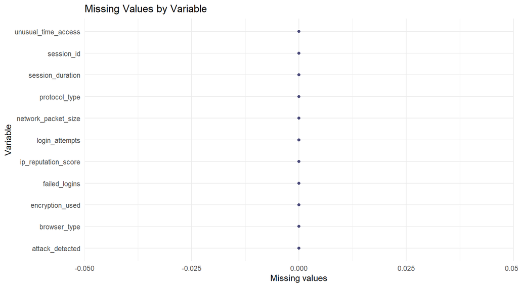

```r
naniar::gg_miss_var(cyber_data) +
  labs(title = "Missing Values by Variable", x = "Variable", y = "Missing values") +
  theme_minimal()
```

**Observation.** The dataset contains 0 missing cells. The text value `None` in `encryption_used` is a valid category meaning that no encryption was used; it is not treated as missing.

```r
duplicate_count <- sum(duplicated(cyber_data))
inconsistent_login_count <- sum(
  cyber_data$failed_logins > cyber_data$login_attempts, na.rm = TRUE
)
data.frame(
  Check = c("Duplicate rows", "Failed logins greater than login attempts"),
  Count = c(duplicate_count, inconsistent_login_count),
  Percent = round(100 * c(duplicate_count, inconsistent_login_count) /
                    nrow(cyber_data), 2)
) |>
  kable(caption = "Duplicate and Logical Consistency Checks") |>
  kable_styling(full_width = FALSE)
```

Duplicate and Logical Consistency Checks

| Check | Count | Percent |
| --- | --- | --- |
| Duplicate rows | 0 | 0.00 |
| Failed logins greater than login attempts | 730 | 7.65 |

**Observation.** There are 0 duplicate rows. However, 730 records (7.65%) contain more failed logins than total login attempts. This may reflect different variable definitions or the synthetic generation process. The records are retained because they may contain genuine attack-related information, but the inconsistency is documented as a limitation.

## 3.2 Target Distribution

```r
cyber_data |>
  count(attack_detected) |>
  mutate(Percent = round(100 * n / sum(n), 2)) |>
  kable(caption = "Attack Class Distribution") |>
  kable_styling(full_width = FALSE)
```

Attack Class Distribution

| attack_detected | n | Percent |
| --- | --- | --- |
| 0 | 5273 | 55.29 |
| 1 | 4264 | 44.71 |

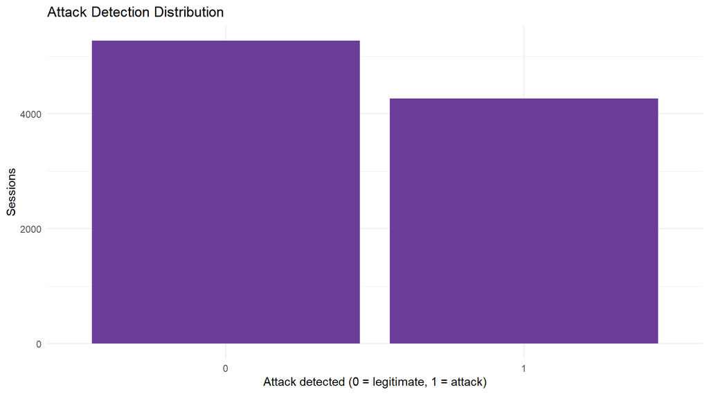

```r
ggplot(cyber_data, aes(x = factor(attack_detected))) +
  geom_bar(fill = "#6A3D9A") +
  labs(title = "Attack Detection Distribution",
       x = "Attack detected (0 = legitimate, 1 = attack)", y = "Sessions") +
  theme_minimal()
```

**Observation.** Attacks represent 44.71% of sessions. The classes are moderately balanced, although legitimate sessions are more common.

## 3.3 Univariate Analysis

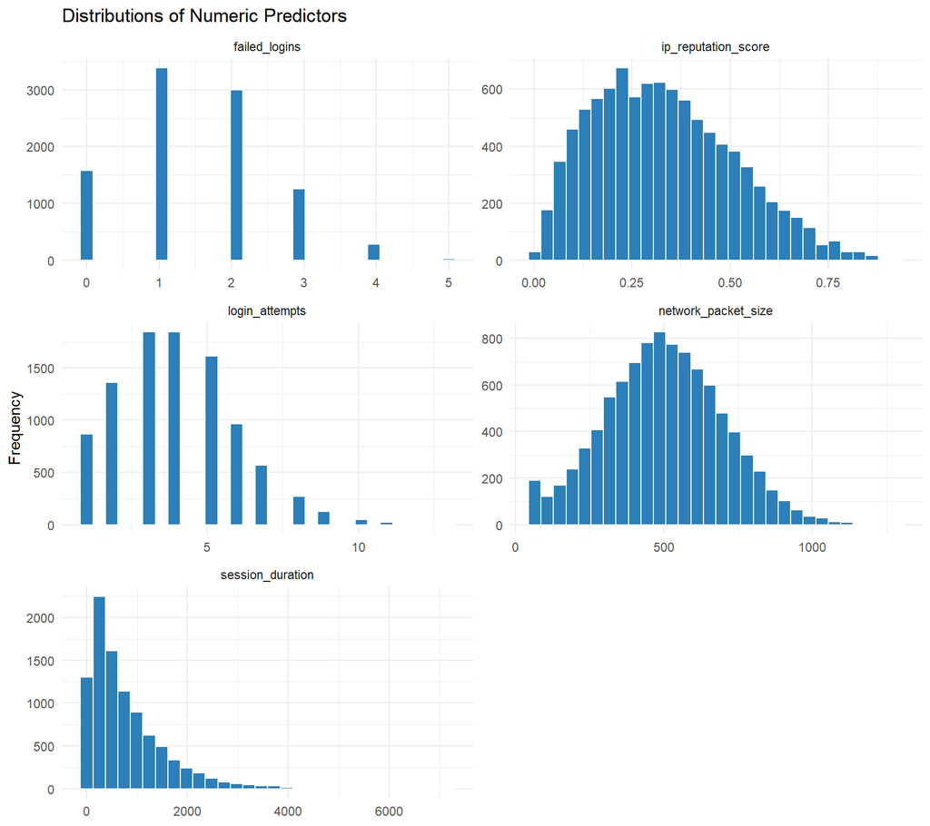

```r
numeric_long <- cyber_data |>
  select(network_packet_size, login_attempts, session_duration,
         ip_reputation_score, failed_logins) |>
  pivot_longer(everything(), names_to = "Variable", values_to = "Value")

ggplot(numeric_long, aes(Value)) +
  geom_histogram(bins = 30, fill = "#2C7FB8", color = "white") +
  facet_wrap(~Variable, scales = "free", ncol = 2) +
  labs(title = "Distributions of Numeric Predictors", x = NULL, y = "Frequency") +
  theme_minimal()
```

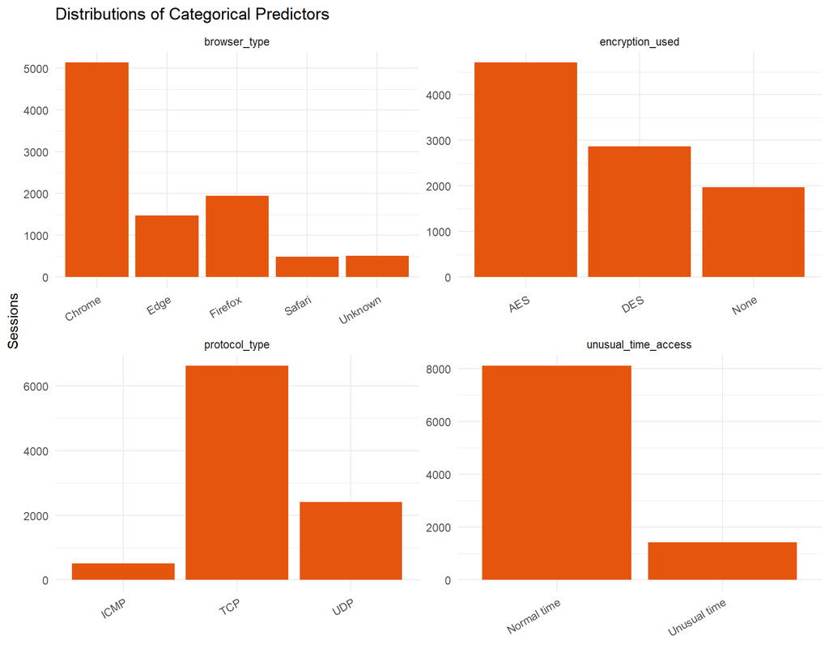

```r
categorical_long <- cyber_data |>
  transmute(
    protocol_type,
    encryption_used,
    browser_type,
    unusual_time_access = factor(unusual_time_access,
                                 levels = c(0, 1),
                                 labels = c("Normal time", "Unusual time"))
  ) |>
  pivot_longer(everything(), names_to = "Variable", values_to = "Category")

ggplot(categorical_long, aes(x = Category)) +
  geom_bar(fill = "#E6550D") +
  facet_wrap(~Variable, scales = "free", ncol = 2) +
  labs(title = "Distributions of Categorical Predictors", x = NULL, y = "Sessions") +
  theme_minimal() +
  theme(axis.text.x = element_text(angle = 30, hjust = 1))
```

**Observation.** TCP, AES and Chrome are the most frequent protocol, encryption and browser categories. Most sessions occur during normal access times. The `None` encryption category represents sessions without encryption and is retained as meaningful information.

## 3.4 Skewness and Transformation Decisions

```r
skew_variables <- c("network_packet_size", "login_attempts", "session_duration",
                    "ip_reputation_score", "failed_logins")

skew_table <- tibble(
  Variable = skew_variables,
  Skewness = round(sapply(cyber_data[skew_variables],
                          e1071::skewness, na.rm = TRUE, type = 2), 3)
) |>
  mutate(
    Interpretation = case_when(
      abs(Skewness) < 0.5 ~ "Approximately symmetric to mildly skewed",
      abs(Skewness) < 1 ~ "Moderately skewed",
      TRUE ~ "Highly skewed"
    ),
    Decision = case_when(
      Variable == "session_duration" ~ "Apply log1p transformation",
      TRUE ~ "No transformation required"
    )
  )

skew_table |>
  kable(caption = "Skewness and Transformation Decisions") |>
  kable_styling(full_width = FALSE)
```

Skewness and Transformation Decisions

| Variable | Skewness | Interpretation | Decision |
| --- | --- | --- | --- |
| network_packet_size | 0.096 | Approximately symmetric to mildly skewed | No transformation required |
| login_attempts | 0.596 | Moderately skewed | No transformation required |
| session_duration | 2.085 | Highly skewed | Apply log1p transformation |
| ip_reputation_score | 0.455 | Approximately symmetric to mildly skewed | No transformation required |
| failed_logins | 0.406 | Approximately symmetric to mildly skewed | No transformation required |

**Observation.** `session_duration` is the only highly skewed continuous predictor and is transformed with `log1p()` during preprocessing. Binary indicators and the binary target are excluded because their asymmetry reflects category proportions rather than a continuous distribution requiring transformation.

## 3.5 Grouped Summary by Attack Status

```r
grouped_summary <- cyber_data |>
  group_by(attack_detected) |>
  summarise(
    Sessions = n(),
    Mean_packet_size = mean(network_packet_size, na.rm = TRUE),
    Mean_login_attempts = mean(login_attempts, na.rm = TRUE),
    Median_session_duration = median(session_duration, na.rm = TRUE),
    Mean_ip_reputation = mean(ip_reputation_score, na.rm = TRUE),
    Mean_failed_logins = mean(failed_logins, na.rm = TRUE),
    Unusual_time_percent = 100 * mean(unusual_time_access, na.rm = TRUE),
    .groups = "drop"
  ) |>
  mutate(across(where(is.numeric), ~round(.x, 2)))

grouped_summary |>
  kable(caption = "Grouped Summary: Legitimate and Attack Sessions") |>
  kable_styling(full_width = FALSE)
```

Grouped Summary: Legitimate and Attack Sessions

| attack_detected | Sessions | Mean_packet_size | Mean_login_attempts | Median_session_duration | Mean_ip_reputation | Mean_failed_logins | Unusual_time_percent |
| --- | --- | --- | --- | --- | --- | --- | --- |
| 0 | 5273 | 501.64 | 3.54 | 554.07 | 0.30 | 1.18 | 14.72 |
| 1 | 4264 | 498.93 | 4.64 | 559.36 | 0.37 | 1.94 | 15.34 |

**Observation.** Attack sessions have higher average login attempts, failed logins and IP reputation scores than legitimate sessions. Packet size and unusual-time access differ very little between the two classes, suggesting that they are weak standalone indicators.

## 3.6 Bivariate Analysis

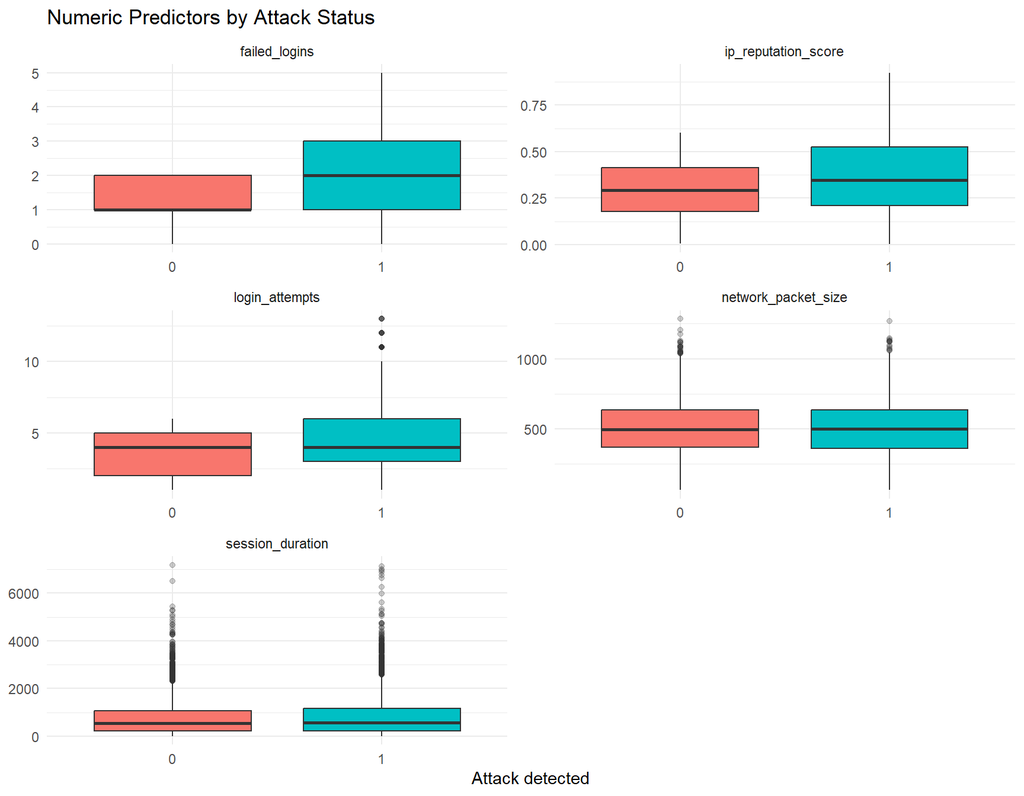

```r
bivariate_long <- cyber_data |>
  select(attack_detected, network_packet_size, login_attempts,
         session_duration, ip_reputation_score, failed_logins) |>
  pivot_longer(-attack_detected, names_to = "Variable", values_to = "Value")

ggplot(bivariate_long,
       aes(x = factor(attack_detected), y = Value,
           fill = factor(attack_detected))) +
  geom_boxplot(outlier.alpha = 0.25) +
  facet_wrap(~Variable, scales = "free", ncol = 2) +
  labs(title = "Numeric Predictors by Attack Status",
       x = "Attack detected", y = NULL, fill = "Attack") +
  theme_minimal() +
  theme(legend.position = "none")
```

**Observation.** Failed logins and login attempts show the clearest separation between classes. IP reputation is also higher among attacks, while packet size distributions overlap almost completely. Session duration contains many high-end observations in both groups.

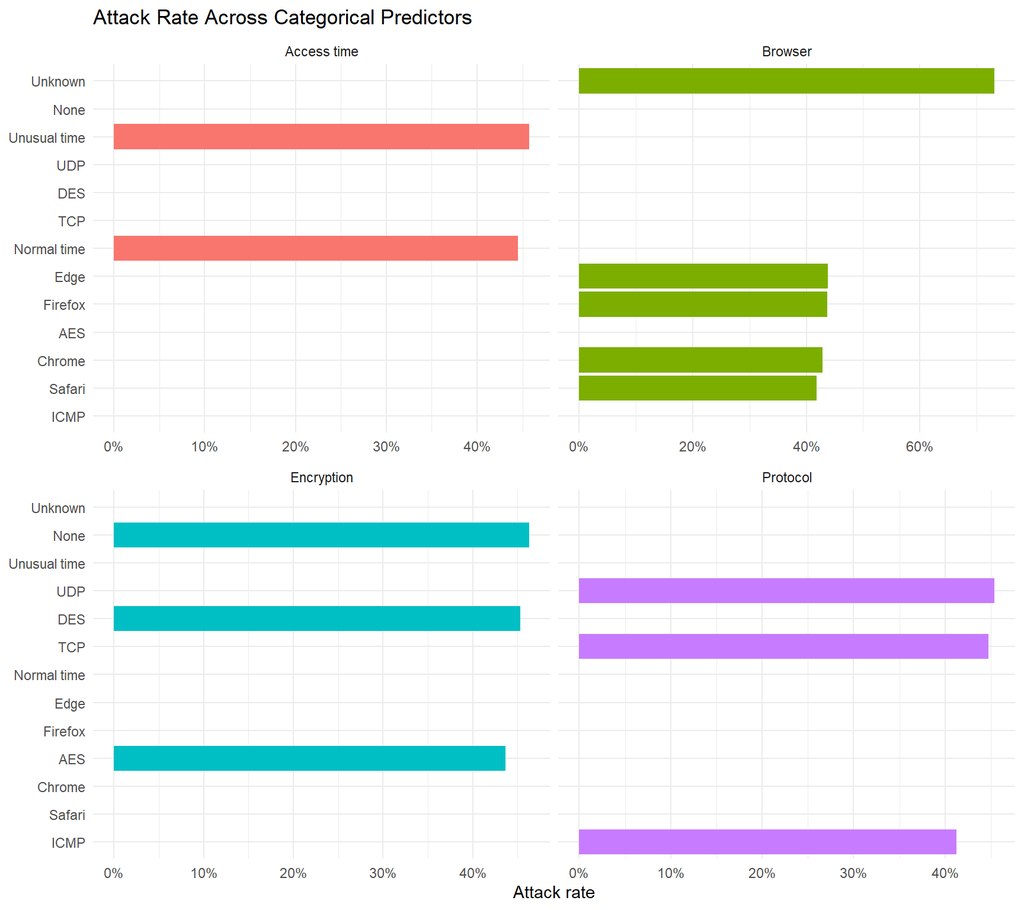

```r
attack_rates <- bind_rows(
  cyber_data |> group_by(Category = protocol_type) |>
    summarise(Attack_rate = mean(attack_detected), n = n(), .groups = "drop") |>
    mutate(Variable = "Protocol"),
  cyber_data |> group_by(Category = encryption_used) |>
    summarise(Attack_rate = mean(attack_detected), n = n(), .groups = "drop") |>
    mutate(Variable = "Encryption"),
  cyber_data |> group_by(Category = browser_type) |>
    summarise(Attack_rate = mean(attack_detected), n = n(), .groups = "drop") |>
    mutate(Variable = "Browser"),
  cyber_data |> mutate(Category = if_else(unusual_time_access == 1,
                                          "Unusual time", "Normal time")) |>
    group_by(Category) |>
    summarise(Attack_rate = mean(attack_detected), n = n(), .groups = "drop") |>
    mutate(Variable = "Access time")
)

ggplot(attack_rates, aes(x = reorder(Category, Attack_rate),
                         y = Attack_rate, fill = Variable)) +
  geom_col(show.legend = FALSE) +
  facet_wrap(~Variable, scales = "free_x") +
  scale_y_continuous(labels = scales::percent_format(accuracy = 1)) +
  coord_flip() +
  labs(title = "Attack Rate Across Categorical Predictors",
       x = NULL, y = "Attack rate") +
  theme_minimal()
```

**Observation.** Browser type shows the most noticeable categorical separation, particularly for the `Unknown` category. Differences among protocol, encryption and access-time categories are comparatively small.

## 3.7 Correlation Analysis

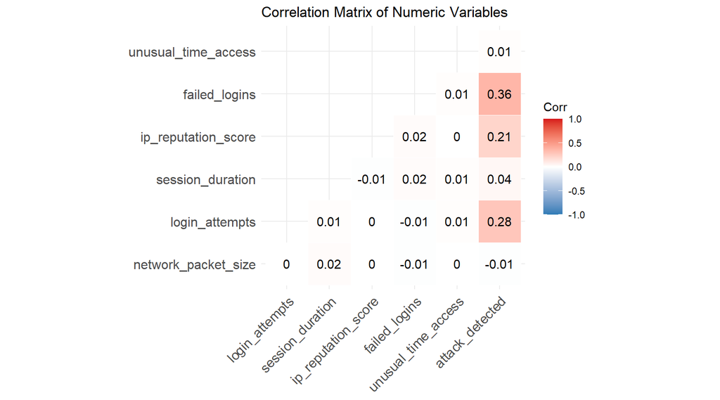

```r
cor_data <- cyber_data |>
  select(network_packet_size, login_attempts, session_duration,
         ip_reputation_score, failed_logins,
         unusual_time_access, attack_detected)
cor_matrix <- cor(cor_data, use = "complete.obs")

ggcorrplot(cor_matrix, lab = TRUE, type = "lower",
           colors = c("#2C7BB6", "white", "#D7191C"),
           outline.color = "white") +
  labs(title = "Correlation Matrix of Numeric Variables")
```

```r
target_correlations <- tibble(
  Variable = setdiff(names(cor_data), "attack_detected"),
  Correlation_with_attack = round(
    cor_matrix[setdiff(names(cor_data), "attack_detected"),
               "attack_detected"], 3)
) |>
  arrange(desc(abs(Correlation_with_attack)))

target_correlations |>
  kable(caption = "Numeric Correlations with Attack Detection") |>
  kable_styling(full_width = FALSE)
```

Numeric Correlations with Attack Detection

| Variable | Correlation_with_attack |
| --- | --- |
| failed_logins | 0.364 |
| login_attempts | 0.277 |
| ip_reputation_score | 0.212 |
| session_duration | 0.042 |
| unusual_time_access | 0.009 |
| network_packet_size | -0.007 |

**Observation.** Failed logins have the strongest positive numeric association with attack detection, followed by login attempts and IP reputation score. Packet size and unusual-time access have correlations close to zero. Correlations among the original predictors are below the 0.80 threshold, so no serious multicollinearity is present before feature engineering.

## 3.8 Non-obvious Finding: Threshold Patterns

```r
threshold_summary <- bind_rows(
  cyber_data |>
    mutate(Group = if_else(login_attempts >= 7,
                           "Login attempts >= 7", "Login attempts < 7")) |>
    group_by(Group) |>
    summarise(Sessions = n(), Attack_rate = mean(attack_detected),
              .groups = "drop") |>
    mutate(Measure = "Login attempts"),
  cyber_data |>
    mutate(Group = if_else(failed_logins >= 3,
                           "Failed logins >= 3", "Failed logins < 3")) |>
    group_by(Group) |>
    summarise(Sessions = n(), Attack_rate = mean(attack_detected),
              .groups = "drop") |>
    mutate(Measure = "Failed logins")
)

threshold_summary |>
  mutate(Attack_rate = scales::percent(Attack_rate, accuracy = 0.1)) |>
  kable(caption = "Attack Rates Around Login Thresholds") |>
  kable_styling(full_width = FALSE)
```

Attack Rates Around Login Thresholds

| Group | Sessions | Attack_rate | Measure |
| --- | --- | --- | --- |
| Login attempts < 7 | 8496 | 37.9% | Login attempts |
| Login attempts >= 7 | 1041 | 100.0% | Login attempts |
| Failed logins < 3 | 7953 | 33.7% | Failed logins |
| Failed logins >= 3 | 1584 | 100.0% | Failed logins |

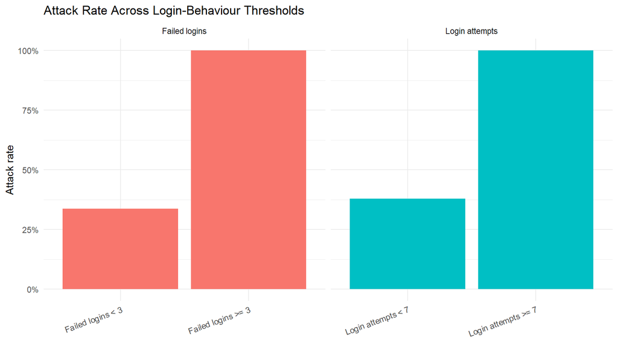

```r
ggplot(threshold_summary,
       aes(x = Group, y = Attack_rate, fill = Measure)) +
  geom_col(show.legend = FALSE) +
  facet_wrap(~Measure, scales = "free_x") +
  scale_y_continuous(labels = scales::percent_format(accuracy = 1),
                     limits = c(0, 1)) +
  labs(title = "Attack Rate Across Login-Behaviour Thresholds",
       x = NULL, y = "Attack rate") +
  theme_minimal() +
  theme(axis.text.x = element_text(angle = 20, hjust = 1))
```

**Observation.** All sessions with seven or more login attempts and all sessions with three or more failed logins are labelled as attacks. This deterministic pattern suggests that the simulated target may have been generated partly from threshold rules. These predictors will be useful for classification, but future model performance may overstate real-world effectiveness.

# 4 Data Preprocessing and Feature Engineering

## 4.1 Missing-Value Treatment

```r
clean_data <- cyber_data
numeric_columns <- names(select(clean_data, where(is.numeric)))
categorical_columns <- names(select(clean_data, where(~is.character(.x) || is.factor(.x))))

numeric_missing_before <- sum(is.na(clean_data[numeric_columns]))
categorical_missing_before <- sum(is.na(clean_data[categorical_columns]))

# Defensive treatment: these operations run only if missing values exist.
for (column in numeric_columns) {
  if (anyNA(clean_data[[column]])) {
    clean_data[[column]][is.na(clean_data[[column]])] <-
      median(clean_data[[column]], na.rm = TRUE)
  }
}
for (column in categorical_columns) {
  if (anyNA(clean_data[[column]])) {
    observed_values <- clean_data[[column]][!is.na(clean_data[[column]])]
    mode_value <- names(sort(table(observed_values), decreasing = TRUE))[1]
    clean_data[[column]][is.na(clean_data[[column]])] <- mode_value
  }
}

missing_treatment <- data.frame(
  Type = c("Numeric", "Categorical", "All columns after treatment"),
  Missing_values = c(numeric_missing_before, categorical_missing_before,
                     sum(is.na(clean_data)))
)
missing_treatment |>
  kable(caption = "Missing-Value Treatment Check") |>
  kable_styling(full_width = FALSE)
```

Missing-Value Treatment Check

| Type | Missing_values |
| --- | --- |
| Numeric | 0 |
| Categorical | 0 |
| All columns after treatment | 0 |

**Observation.** No values required replacement in the current dataset. The conditional median and mode procedures are included defensively so the document remains reproducible if future versions contain missing values. The valid `None` encryption category is unchanged.

## 4.2 Duplicate Treatment

```r
rows_before <- nrow(clean_data)
clean_data <- clean_data |> distinct()
rows_after <- nrow(clean_data)
data.frame(Rows_before = rows_before,
           Duplicates_removed = rows_before - rows_after,
           Rows_after = rows_after) |>
  kable(caption = "Duplicate Treatment") |>
  kable_styling(full_width = FALSE)
```

Duplicate Treatment

| Rows_before | Duplicates_removed | Rows_after |
| --- | --- | --- |
| 9537 | 0 | 9537 |

**Observation.** 0 duplicate rows were removed. The unique `session_id` remains available for record tracking but is excluded from the modelling predictors.

## 4.3 Outlier Detection and Treatment

```r
outlier_variables <- c("network_packet_size", "login_attempts",
                       "session_duration", "ip_reputation_score",
                       "failed_logins")

outlier_table <- map_dfr(outlier_variables, function(column) {
  values <- clean_data[[column]]
  q1 <- quantile(values, 0.25, na.rm = TRUE)
  q3 <- quantile(values, 0.75, na.rm = TRUE)
  iqr_value <- q3 - q1
  lower <- q1 - 1.5 * iqr_value
  upper <- q3 + 1.5 * iqr_value
  count <- sum(values < lower | values > upper, na.rm = TRUE)
  tibble(Variable = column, Lower_bound = lower, Upper_bound = upper,
         Outlier_count = count, Percent = 100 * count / length(values))
}) |>
  mutate(across(where(is.numeric), ~round(.x, 2)))

outlier_table |>
  kable(caption = "IQR Outlier Counts") |>
  kable_styling(full_width = FALSE)
```

IQR Outlier Counts

| Variable | Lower_bound | Upper_bound | Outlier_count | Percent |
| --- | --- | --- | --- | --- |
| network_packet_size | -40.00 | 1040.00 | 37 | 0.39 |
| login_attempts | 0.00 | 8.00 | 206 | 2.16 |
| session_duration | -1078.19 | 2415.52 | 418 | 4.38 |
| ip_reputation_score | -0.20 | 0.85 | 21 | 0.22 |
| failed_logins | -0.50 | 3.50 | 323 | 3.39 |

**Observation.** Outliers are retained because unusually long sessions, high login activity and extreme reputation values may represent meaningful security events rather than data-entry errors. Strongly skewed session duration is handled with a log transformation instead of deleting observations. This preserves potentially important attack information.

## 4.4 Feature Engineering

```r
engineered_data <- clean_data |>
  mutate(
    failed_login_ratio = failed_logins / login_attempts,

    login_count_inconsistency = if_else(
      failed_logins > login_attempts,
      1L,
      0L
    ),

    log_session_duration = log1p(session_duration)
  )

engineered_data |>
  select(
    session_id,
    failed_logins,
    login_attempts,
    failed_login_ratio,
    login_count_inconsistency,
    session_duration,
    log_session_duration
  ) |>
  head() |>
  kable(caption = "Preview of Engineered Features") |>
  kable_styling(full_width = FALSE)
```

Preview of Engineered Features

| session_id | failed_logins | login_attempts | failed_login_ratio | login_count_inconsistency | session_duration | log_session_duration |
| --- | --- | --- | --- | --- | --- | --- |
| SID_00001 | 1 | 4 | 0.2500000 | 0 | 492.98326 | 6.202502 |
| SID_00002 | 0 | 3 | 0.0000000 | 0 | 1557.99646 | 7.351798 |
| SID_00003 | 2 | 3 | 0.6666667 | 0 | 75.04426 | 4.331316 |
| SID_00004 | 0 | 4 | 0.0000000 | 0 | 601.24884 | 6.400671 |
| SID_00005 | 1 | 5 | 0.2000000 | 0 | 532.54089 | 6.279536 |
| SID_00006 | 2 | 5 | 0.4000000 | 0 | 380.47155 | 5.944036 |

```r
engineered_feature_summary <- engineered_data |>
  summarise(
    Inconsistent_sessions = sum(login_count_inconsistency),
    Inconsistent_percent = round(
      100 * mean(login_count_inconsistency),
      2
    ),
    Attack_rate_in_inconsistent_sessions = round(
      100 * mean(
        attack_detected[login_count_inconsistency == 1]
      ),
      2
    )
  )

engineered_feature_summary |>
  kable(
    caption = "Summary of Login-Count Inconsistency"
  ) |>
  kable_styling(full_width = FALSE)
```

Summary of Login-Count Inconsistency

| Inconsistent_sessions | Inconsistent_percent | Attack_rate_in_inconsistent_sessions |
| --- | --- | --- |
| 730 | 7.65 | 70.68 |

**Observation.** Two behavioural features were engineered. `failed_login_ratio` measures failed logins relative to total login attempts, providing a normalized indicator of login pressure. `login_count_inconsistency` identifies sessions where failed logins exceed total login attempts, capturing a documented logical inconsistency that may also represent abnormal or attack related behaviour. In addition, `log_session_duration` was created to reduce the strong positive skew of session duration while preserving the ordering of session lengths.

## 4.5 Categorical Encoding

```r
model_data <- engineered_data |>
  select(-session_id) |>
  mutate(
    attack_detected = factor(attack_detected, levels = c(0, 1)),
    protocol_type = factor(protocol_type),
    encryption_used = factor(encryption_used),
    browser_type = factor(browser_type)
  )

dummy_encoder <- caret::dummyVars(
  attack_detected ~ ., data = model_data, fullRank = TRUE
)
encoded_predictors <- as.data.frame(predict(dummy_encoder, newdata = model_data))
encoded_data <- bind_cols(
  encoded_predictors,
  attack_detected = model_data$attack_detected
)

dim(encoded_data)
```

```
## [1] 9537   18
```

```r
head(encoded_data) |>
  kable(caption = "Preview After One-Hot Encoding") |>
  kable_styling(full_width = FALSE)
```

Preview After One-Hot Encoding

| network_packet_size | protocol_type.TCP | protocol_type.UDP | login_attempts | session_duration | encryption_used.DES | encryption_used.None | ip_reputation_score | failed_logins | browser_type.Edge | browser_type.Firefox | browser_type.Safari | browser_type.Unknown | unusual_time_access | failed_login_ratio | login_count_inconsistency | log_session_duration | attack_detected |
| --- | --- | --- | --- | --- | --- | --- | --- | --- | --- | --- | --- | --- | --- | --- | --- | --- | --- |
| 599 | 1 | 0 | 4 | 492.98326 | 1 | 0 | 0.6068181 | 1 | 1 | 0 | 0 | 0 | 0 | 0.2500000 | 0 | 6.202502 | 1 |
| 472 | 1 | 0 | 3 | 1557.99646 | 1 | 0 | 0.3015690 | 0 | 0 | 1 | 0 | 0 | 0 | 0.0000000 | 0 | 7.351798 | 0 |
| 629 | 1 | 0 | 3 | 75.04426 | 1 | 0 | 0.7391643 | 2 | 0 | 0 | 0 | 0 | 0 | 0.6666667 | 0 | 4.331316 | 1 |
| 804 | 0 | 1 | 4 | 601.24884 | 1 | 0 | 0.1232672 | 0 | 0 | 0 | 0 | 1 | 0 | 0.0000000 | 0 | 6.400671 | 1 |
| 453 | 1 | 0 | 5 | 532.54089 | 0 | 0 | 0.0548739 | 1 | 0 | 1 | 0 | 0 | 0 | 0.2000000 | 0 | 6.279536 | 0 |
| 453 | 0 | 1 | 5 | 380.47155 | 0 | 0 | 0.4224859 | 2 | 0 | 0 | 0 | 0 | 1 | 0.4000000 | 0 | 5.944036 | 0 |

**Observation.** Nominal categorical predictors are converted into numeric dummy variables using full-rank encoding. The target remains a two-level factor and `session_id` is excluded because it is a unique identifier rather than a meaningful predictor.

## 4.6 Numeric Scaling

```r
scaled_data <- encoded_data
predictor_names <- setdiff(names(scaled_data), "attack_detected")
scaled_data[predictor_names] <- scale(scaled_data[predictor_names])

scaling_check <- scaled_data |>
  select(all_of(predictor_names)) |>
  summarise(across(everything(), list(mean = mean, sd = sd))) |>
  pivot_longer(everything(), names_to = "Measure", values_to = "Value") |>
  head(12)

scaling_check |>
  mutate(Value = round(Value, 3)) |>
  kable(caption = "Scaling Check: Selected Means and Standard Deviations") |>
  kable_styling(full_width = FALSE)
```

Scaling Check: Selected Means and Standard Deviations

| Measure | Value |
| --- | --- |
| network_packet_size_mean | 0 |
| network_packet_size_sd | 1 |
| protocol_type.TCP_mean | 0 |
| protocol_type.TCP_sd | 1 |
| protocol_type.UDP_mean | 0 |
| protocol_type.UDP_sd | 1 |
| login_attempts_mean | 0 |
| login_attempts_sd | 1 |
| session_duration_mean | 0 |
| session_duration_sd | 1 |
| encryption_used.DES_mean | 0 |
| encryption_used.DES_sd | 1 |

**Observation.** Predictors are standardized to comparable scales, supporting distance-based methods and PCA in Phase 2. During Phase 2 modelling, scaling parameters should be estimated from the training partition and applied to the test partition to avoid data leakage.

## 4.7 Feature Selection

```r
selection_predictors <- scaled_data |> select(-attack_detected)

nzv_indices <- caret::nearZeroVar(selection_predictors)
nzv_removed <- if (length(nzv_indices) == 0) character(0) else
  names(selection_predictors)[nzv_indices]

after_nzv <- if (length(nzv_indices) == 0) selection_predictors else
  selection_predictors[, -nzv_indices, drop = FALSE]

correlation_matrix <- cor(after_nzv, use = "complete.obs")
high_cor_indices <- caret::findCorrelation(correlation_matrix,
                                           cutoff = 0.80,
                                           names = FALSE,
                                           exact = TRUE)
high_cor_removed <- if (length(high_cor_indices) == 0) character(0) else
  names(after_nzv)[high_cor_indices]

selected_predictors <- if (length(high_cor_indices) == 0) after_nzv else
  after_nzv[, -high_cor_indices, drop = FALSE]

selection_summary <- data.frame(
  Method = c("Near-zero variance filter", "Correlation filter (> 0.80)"),
  Removed_count = c(length(nzv_removed), length(high_cor_removed)),
  Removed_features = c(
    ifelse(length(nzv_removed) == 0, "None", paste(nzv_removed, collapse = ", ")),
    ifelse(length(high_cor_removed) == 0, "None", paste(high_cor_removed, collapse = ", "))
  )
)
selection_summary |>
  kable(caption = "Feature Selection Results") |>
  kable_styling(full_width = FALSE)
```

Feature Selection Results

| Method | Removed_count | Removed_features |
| --- | --- | --- |
| Near-zero variance filter | 0 | None |
| Correlation filter (> 0.80) | 1 | protocol_type.UDP |

**Observation.** Feature selection is applied programmatically rather than by manually dropping columns. Near-zero variance predictors are removed first, followed by one feature from each predictor pair exceeding an absolute correlation of 0.80. The displayed table reports the actual retained/removed result from the current data.

## 4.8 Final Phase 2 Data Frame

```r
final_phase2_data <- bind_cols(
  selected_predictors,
  attack_detected = scaled_data$attack_detected
)

data.frame(
  Rows = nrow(final_phase2_data),
  Columns = ncol(final_phase2_data),
  Missing_values = sum(is.na(final_phase2_data))
) |>
  kable(caption = "Final Phase 2 Data Frame Summary") |>
  kable_styling(full_width = FALSE)
```

Final Phase 2 Data Frame Summary

| Rows | Columns | Missing_values |
| --- | --- | --- |
| 9537 | 17 | 0 |

```r
glimpse(final_phase2_data)
```

```
## Rows: 9,537
## Columns: 17
## $ network_packet_size       <dbl> 0.49687306, -0.14331450, 0.64809847, 1.53024…
## $ protocol_type.TCP         <dbl> 0.6631126, 0.6631126, 0.6631126, -1.5078813,…
## $ login_attempts            <dbl> -0.01634507, -0.52576626, -0.52576626, -0.01…
## $ session_duration          <dbl> -0.38110506, 0.97290863, -0.91245540, -0.243…
## $ encryption_used.DES       <dbl> 1.5259592, 1.5259592, 1.5259592, 1.5259592, …
## $ encryption_used.None      <dbl> -0.5095565, -0.5095565, -0.5095565, -0.50955…
## $ ip_reputation_score       <dbl> 1.55484850, -0.16802062, 2.30182941, -1.1743…
## $ failed_logins             <dbl> -0.5007532, -1.4678823, 0.4663759, -1.467882…
## $ browser_type.Edge         <dbl> 2.3434154, -0.4266828, -0.4266828, -0.426682…
## $ browser_type.Firefox      <dbl> -0.5059629, 1.9762223, -0.5059629, -0.505962…
## $ browser_type.Safari       <dbl> -0.2314599, -0.2314599, -0.2314599, -0.23145…
## $ browser_type.Unknown      <dbl> -0.2357029, -0.2357029, -0.2357029, 4.242183…
## $ unusual_time_access       <dbl> -0.419967, -0.419967, -0.419967, -0.419967, …
## $ failed_login_ratio        <dbl> -0.47761236, -0.92048373, 0.26050660, -0.920…
## $ login_count_inconsistency <dbl> -0.2878887, -0.2878887, -0.2878887, -0.28788…
## $ log_session_duration      <dbl> 0.06465879, 0.99279176, -1.44644849, 0.22469…
## $ attack_detected           <fct> 1, 0, 1, 1, 0, 0, 1, 1, 0, 0, 1, 1, 0, 1, 1,…
```

**Observation.** `final_phase2_data` contains the cleaned, engineered, encoded, standardized and selected features together with the binary target. It is the single prepared data frame to be used as the basis for Phase 2 modelling.

# Conclusion

The dataset meets the project requirements and is suitable for binary classification. EDA shows that failed logins, login attempts and IP reputation have the clearest associations with attack status, while packet size and unusual-time access have weak standalone relationships. Session duration is strongly right-skewed and is log-transformed. No missing or duplicate records require correction, although a logical inconsistency between failed logins and total attempts is documented. Two meaningful features are engineered, categorical predictors are one-hot encoded, numeric predictors are standardized, and principled variance and correlation filters are applied. The resulting `final_phase2_data` object is prepared for Phase 2, with the important limitation that deterministic attack thresholds in this simulated dataset may make future model performance appear more generalisable than it is.